# Open Science Workflow Training for ISC – day-1-pres-github_basics

GitHub for Collaborative Workflows

Megumi Oshima & Nicholas Ducharme-Barth

January 2025

## Version Control

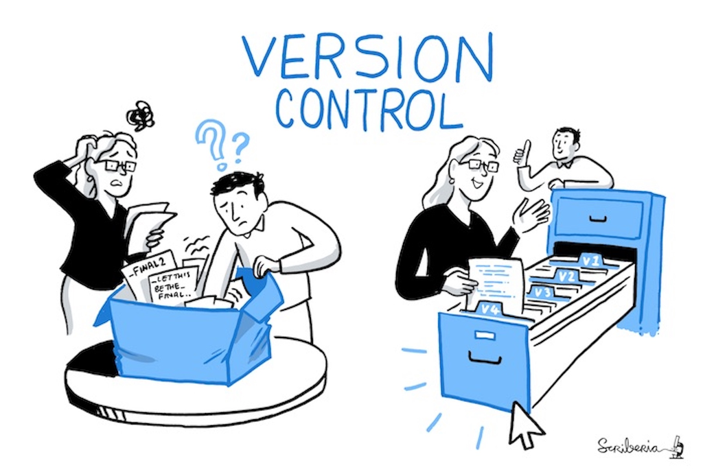

The Turing Way Community. This illustration is created by Scriberia with The Turing Way community, used under a CC-BY 4.0 licence. DOI: 10.5281/zenodo.3332807

## Git and GitHub

installed on local computer

tracks changes to files

separate versions

central, remote storage of files

everyone can contribute changes

changes can be combined and shared

We can leverage the interplay between both to help us share code and collaborate with others!

## Basic Git/Github Workflow

[figure not shown]

## Remote repository on Github

### (リモートリポジトリ)

- Where all of your code and related files lives online
- Central location where everyone is sharing their changes
- Many ways to work with GitHub

## Local repository

### (ローカルリポジトリ)

- Files kept on your local computer
- Includes branches from the remote repository
  - allows for different versions of the same file
- Different from local working directory

## Connecting remote and local repositories

- `git clone` - if you started the repository on GitHub
- `git init` - if you started the repository on your computer

## Making changes locally

[figure not shown]

## Commits

### (コミット)

- groups of small, meaningful changes
- snapshots of your repository at that time
- tell a story of the history of your repository

## Commits

### (コミット)

Make a commit in 2 stages:

1. save your changes locally and then **stage** the files you want to commit

   `git add <FILENAME>`
2. **commit** your changes

   `git commit -m "descriptive commit message"`

## Push

### (プッシュ)

To sync the changes you’ve made locally with the remote repository, you need to **“PUSH”** your commits

`git push`

## Pull

### (プル)

To sync changes *from* the remote repository *to* your local computer you need to **“PULL”** commits

2 ways:  
1. `git pull`

2. `git fetch`, then eventually `git merge`

## Branches

### (ブランチ)

The default for all repositories is `main`

[figure not shown]

# Live Demo

Let’s make our first commit!

## Activity

1. Following the template provided here, create a new Markdown document (`.md`) with:
- A list of everyone in your group, including:
  - their affiliation
  - their GitHub name
- a picture of a species you work on
- a code chunk with your most used function
- a task list of three things you would like to learn from the workshop
2. Save the file with a new name.
3. Commit your file, and push to the repository.